# TABASCO-MEXCOV-19

Andrea Cicchini, Rossella Marvulli, Victor Plesco

July 3, 2020

# Index

- Introduction
- Descriptive Analysis
- Logistic Regression
- Autoregressive Model (ARIMA)

# Introduction

### Data

The data used within this [project](https://github.com/vrpo/TABASCO-MEXCOV-19) has been gathered from the [government of Mexico’s website](https://www.gob.mx/salud/documentos/datos-abiertos-152127) and is composed of `528.651` records related to the executed swabs, having as purpose the detection of covid infections, across the states of Mexico between `2020-01-01` and `2020-06-25`. Each record specifies the **`Gender`** and **`Age`** of the unit on which the swab was executed, the **`State`** and **`Region`** in which the test was executed, the **`swab_Date`** of execution, alongside with the **`WeekDays`**, and its **`Result`**.

| Gender | Age.Labels | State | Region | swab_Date | WeekDays | Result |
| --- | --- | --- | --- | --- | --- | --- |
| Female | 62+ | COAHUILA DE ZARAGOZA | North | 2020-03-09 | Monday | Negative |
| Male | 42-47 | NUEVO LEÓN | Center | 2020-03-12 | Thursday | Negative |
| Male | 42-47 | CIUDAD DE MÉXICO | Center | 2020-03-09 | Monday | Positive |
| Male | 62+ | DURANGO | North | 2020-03-15 | Sunday | Positive |
| Male | 32-36 | SONORA | North | 2020-03-11 | Wednesday | Negative |
| Male | 54-62 | JALISCO | Center | 2020-03-13 | Friday | Positive |

### Train, Test & Real Set

For the testing purpose we proceed with a `80/20` split of the dataset and concentrate our analyses only on the central states of Mexico. Alongside the latter reductions we impose a temporal limit to the records (i.e. the data used for training and testing our models) which is the period in between `2020-03-07` and `2020-04-18`. Lastly we define the `Real` set, composed of the executed swabs from `2020-04-19` to `2020-06-25`, for visualizing our prediction over a longer period of time.

# Descriptive Analysis

### Age.Labels

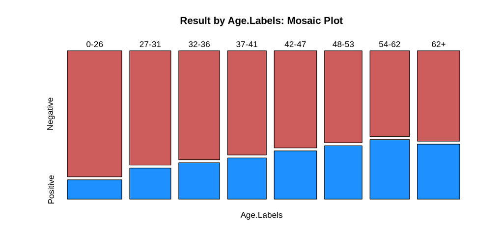

```r
chisq.test(age.table)
```

```
    Pearson's Chi-squared test

data:  age.table
X-squared = 2413.9, df = 7, p-value < 2.2e-16
```

```r
CramerV(age.table)
```

```
[1] 0.202165
```

### Gender

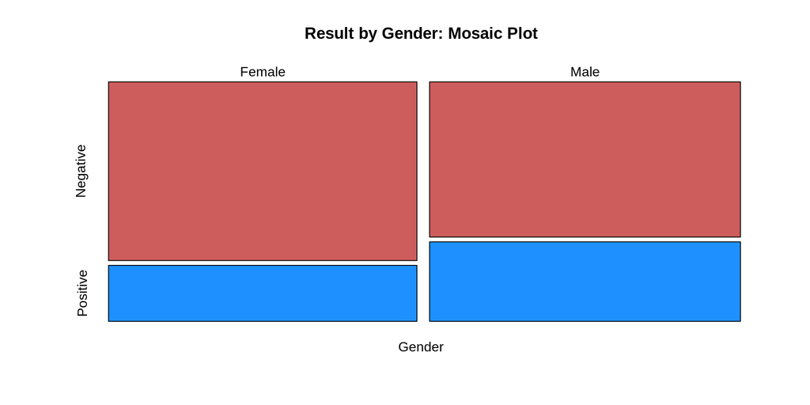

```r
chisq.test(gender.table)
```

```
    Pearson's Chi-squared test with Yates' continuity correction

data:  gender.table
X-squared = 720.97, df = 1, p-value < 2.2e-16
```

```r
CramerV(gender.table)
```

```
[1] 0.1105233
```

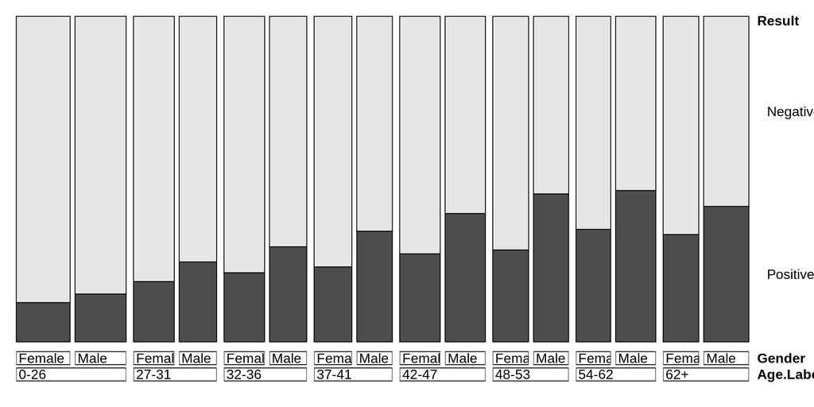

```r
gender.age.table <- with(data, table(Result, Gender, Age.Labels))
with(data, my_mantelhaen.test(gender.age.table, alternative = "two.sided"))
```

```
    Mantel-Haenszel chi-squared test with continuity correction

data:  gender.age.table
Mantel-Haenszel X-squared = 652.07, df = 1, p-value < 2.2e-16
alternative hypothesis: true common odds ratio is not equal to 1
95 percent confidence interval:
 1.552823 1.671192
sample estimates:
common odds ratio
         1.610921
```

### WeekDays

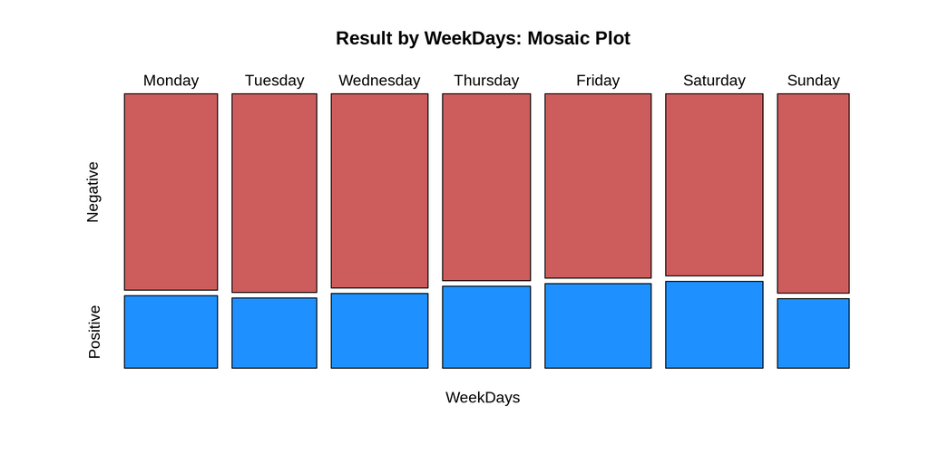

```r
chisq.test(weekdays.table)
```

```
    Pearson's Chi-squared test

data:  weekdays.table
X-squared = 172.04, df = 6, p-value < 2.2e-16
```

```r
CramerV(weekdays.table)
```

```
[1] 0.05397187
```

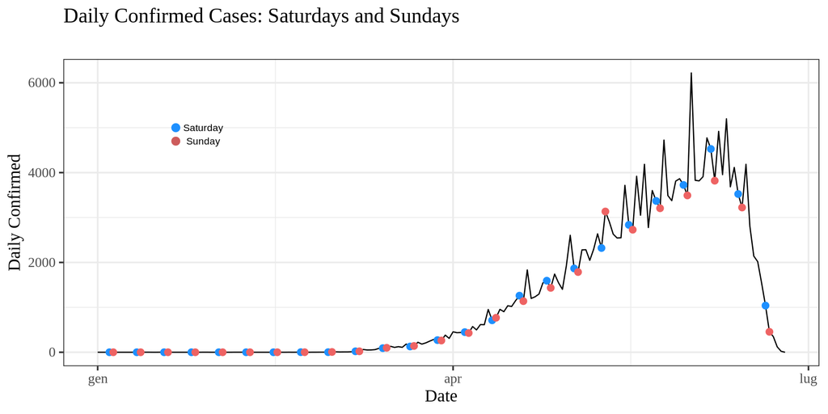

### State

```r
chisq.test(state.table)
```

```
    Pearson's Chi-squared test

data:  state.table
X-squared = 6706, df = 31, p-value < 2.2e-16
```

```r
CramerV(state.table)
```

```
[1] 0.336962
```

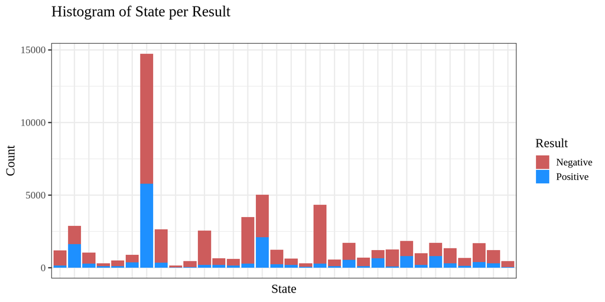

# Logistic Regression

### Model Evaluation

```
Call:
glm(formula = Result ~ Age.Labels + Gender + WeekDays + State,
    family = binomial(link = "logit"), data = train_set)

Deviance Residuals:
    Min       1Q   Median       3Q      Max
-1.4121  -0.8320  -0.4588   1.0354   2.7754

Coefficients:
                         Estimate Std. Error z value Pr(>|z|)
(Intercept)              -2.81718    0.10899 -25.849  < 2e-16 ***
Age.Labels27-31           0.40724    0.05912   6.888 5.65e-12 ***
Age.Labels32-36           0.51108    0.05849   8.738  < 2e-16 ***
Age.Labels37-41           0.70974    0.05785  12.268  < 2e-16 ***
Age.Labels42-47           0.90681    0.05580  16.252  < 2e-16 ***
Age.Labels48-53           1.04298    0.05675  18.379  < 2e-16 ***
Age.Labels54-62           1.29450    0.05531  23.403  < 2e-16 ***
Age.Labels62+             1.19586    0.05474  21.846  < 2e-16 ***
GenderMale                0.51100    0.02730  18.721  < 2e-16 ***
WeekDaysTuesday          -0.04513    0.05234  -0.862 0.388500
WeekDaysWednesday        -0.02745    0.04993  -0.550 0.582479
WeekDaysThursday          0.06750    0.05096   1.324 0.185346
WeekDaysFriday            0.18954    0.04825   3.929 8.54e-05 ***
WeekDaysSaturday          0.19065    0.04927   3.869 0.000109 ***
WeekDaysSunday           -0.11290    0.05550  -2.034 0.041904 *
StateCIUDAD DE MÉXICO     1.26437    0.09772  12.938  < 2e-16 ***
StateCOLIMA              -0.14616    0.27640  -0.529 0.596937
StateGUANAJUATO          -0.65166    0.12671  -5.143 2.71e-07 ***
StateGUERRERO             0.82022    0.13742   5.968 2.39e-09 ***
StateHIDALGO              0.65304    0.14355   4.549 5.38e-06 ***
StateJALISCO             -0.72808    0.11930  -6.103 1.04e-09 ***
StateMÉXICO               1.35764    0.10134  13.397  < 2e-16 ***
StateMICHOACÁN DE OCAMPO  0.27167    0.12676   2.143 0.032100 *
StateMORELOS              0.84036    0.13746   6.113 9.75e-10 ***
StateNAYARIT              0.24195    0.19073   1.269 0.204595
StateNUEVO LEÓN          -0.89976    0.11794  -7.629 2.37e-14 ***
StatePUEBLA               0.94410    0.11291   8.361  < 2e-16 ***
StateQUERÉTARO            0.20652    0.15034   1.374 0.169527
StateSAN LUIS POTOSÍ     -0.79238    0.15760  -5.028 4.96e-07 ***
StateTAMAULIPAS           0.52270    0.12142   4.305 1.67e-05 ***
StateTLAXCALA             0.40169    0.14513   2.768 0.005646 **
StateZACATECAS           -0.26985    0.19376  -1.393 0.163702
---
Signif. codes:  0 '***' 0.001 '**' 0.01 '*' 0.05 '.' 0.1 ' ' 1

(Dispersion parameter for binomial family taken to be 1)

    Null deviance: 38029  on 32915  degrees of freedom
Residual deviance: 32776  on 32884  degrees of freedom
AIC: 32840

Number of Fisher Scoring iterations: 5
```

#### Anova

```
Analysis of Deviance Table

Model 1: Result ~ Age.Labels
Model 2: Result ~ Age.Labels + Gender
Model 3: Result ~ Age.Labels + Gender + WeekDays
Model 4: Result ~ Age.Labels + Gender + WeekDays + State
  Resid. Df Resid. Dev Df Deviance  Pr(>Chi)
1     32908      36669
2     32907      36264  1    404.4 < 2.2e-16 ***
3     32901      36179  6     85.2 3.061e-16 ***
4     32884      32776 17   3403.6 < 2.2e-16 ***
---
Signif. codes:  0 '***' 0.001 '**' 0.01 '*' 0.05 '.' 0.1 ' ' 1
```

#### McFadden

```
            Model 1    Model 2    Model 3   Model 4
McFadden 0.03578004 0.04641285 0.04865213 0.1381506
```

#### ROC Curve

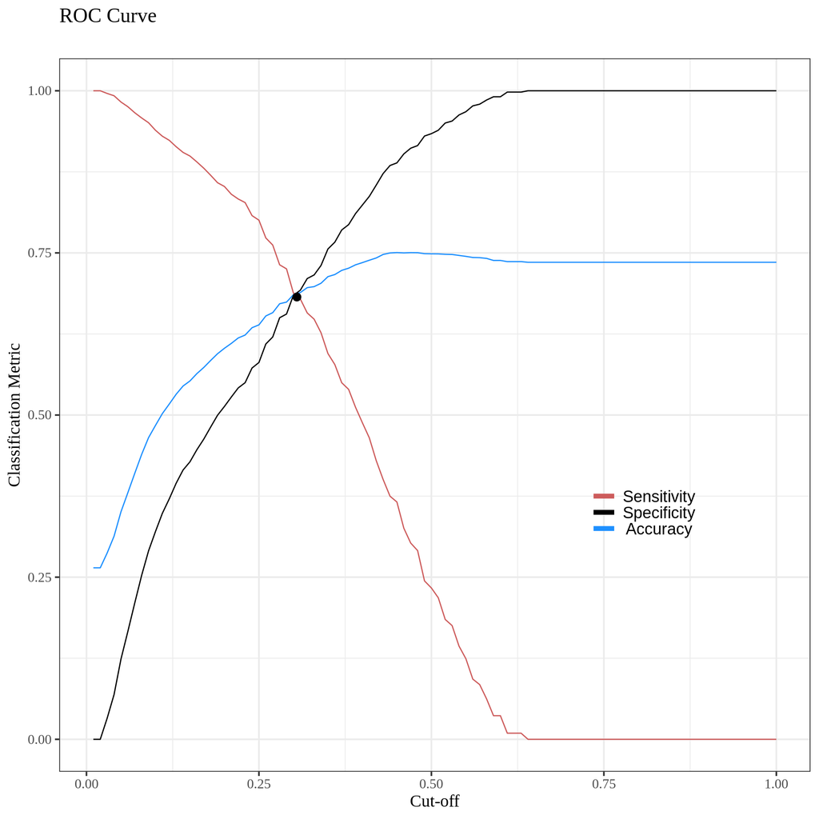

### Prediction

#### Test Set

```
Confusion Matrix and Statistics

          Reference
Prediction Negative Positive
  Negative     4107      648
  Positive     1873     1547

               Accuracy : 0.6916
                 95% CI : (0.6815, 0.7016)
    No Information Rate : 0.7315
    P-Value [Acc > NIR] : 1

                  Kappa : 0.3328

 Mcnemar's Test P-Value : <2e-16

            Sensitivity : 0.7048
            Specificity : 0.6868
         Pos Pred Value : 0.4523
         Neg Pred Value : 0.8637
             Prevalence : 0.2685
         Detection Rate : 0.1892
   Detection Prevalence : 0.4183
      Balanced Accuracy : 0.6958

       'Positive' Class : Positive
```

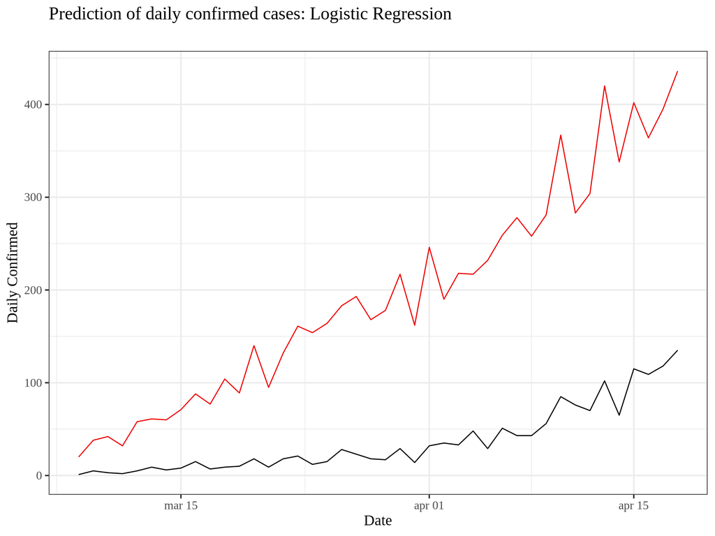

#### Real Set

```
Confusion Matrix and Statistics

          Reference
Prediction Negative Positive
  Negative    96978    51872
  Positive    56453    65735

               Accuracy : 0.6003
                 95% CI : (0.5985, 0.6022)
    No Information Rate : 0.5661
    P-Value [Acc > NIR] : < 2.2e-16

                  Kappa : 0.1901

 Mcnemar's Test P-Value : < 2.2e-16

            Sensitivity : 0.5589
            Specificity : 0.6321
         Pos Pred Value : 0.5380
         Neg Pred Value : 0.6515
             Prevalence : 0.4339
         Detection Rate : 0.2425
   Detection Prevalence : 0.4508
      Balanced Accuracy : 0.5955

       'Positive' Class : Positive
```

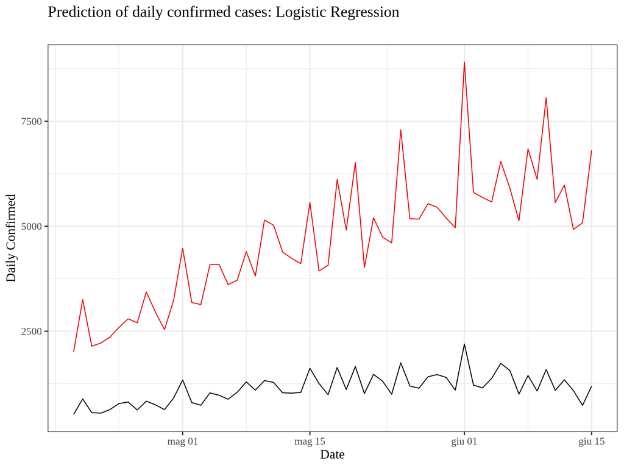

# Autoregressive Model (ARIMA)

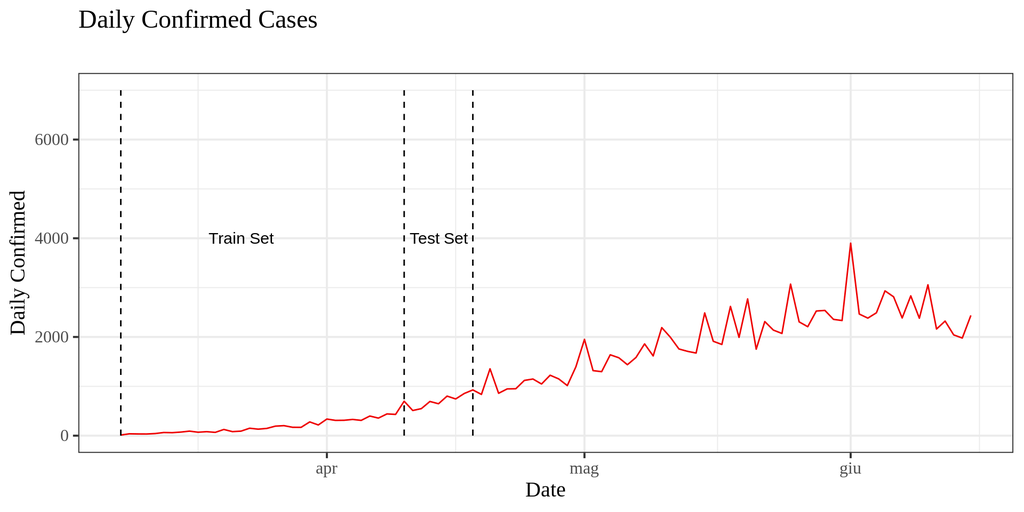

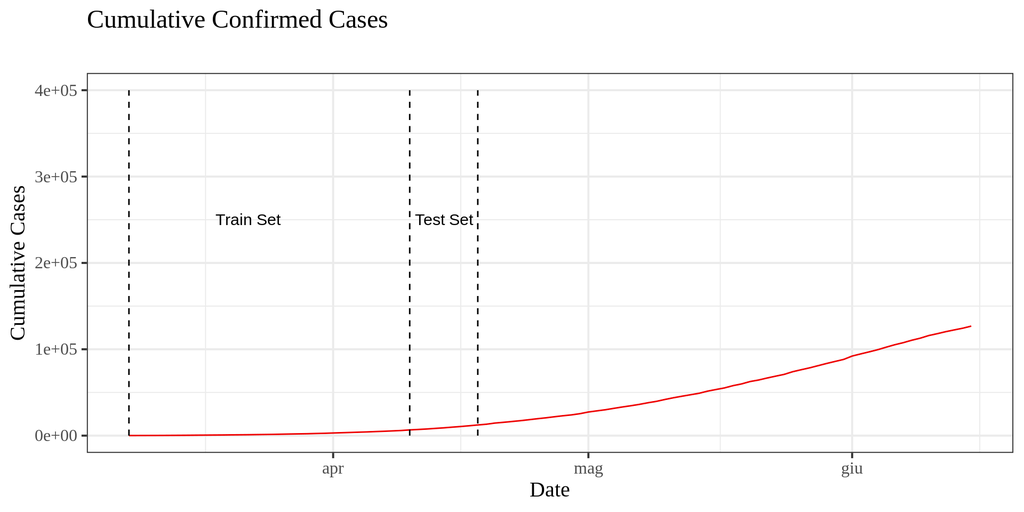

# STATIONARITY of TIME SERIES

- Stationary time series $\longmapsto$ statistical moments until a certain order are time-independent
- Non-stationary time series $\longmapsto$ statistical moments depend on time

Two way to detect the (non) stationarity:

- ACF and PACF
- Box-Ljung Test

# ACF and PACF

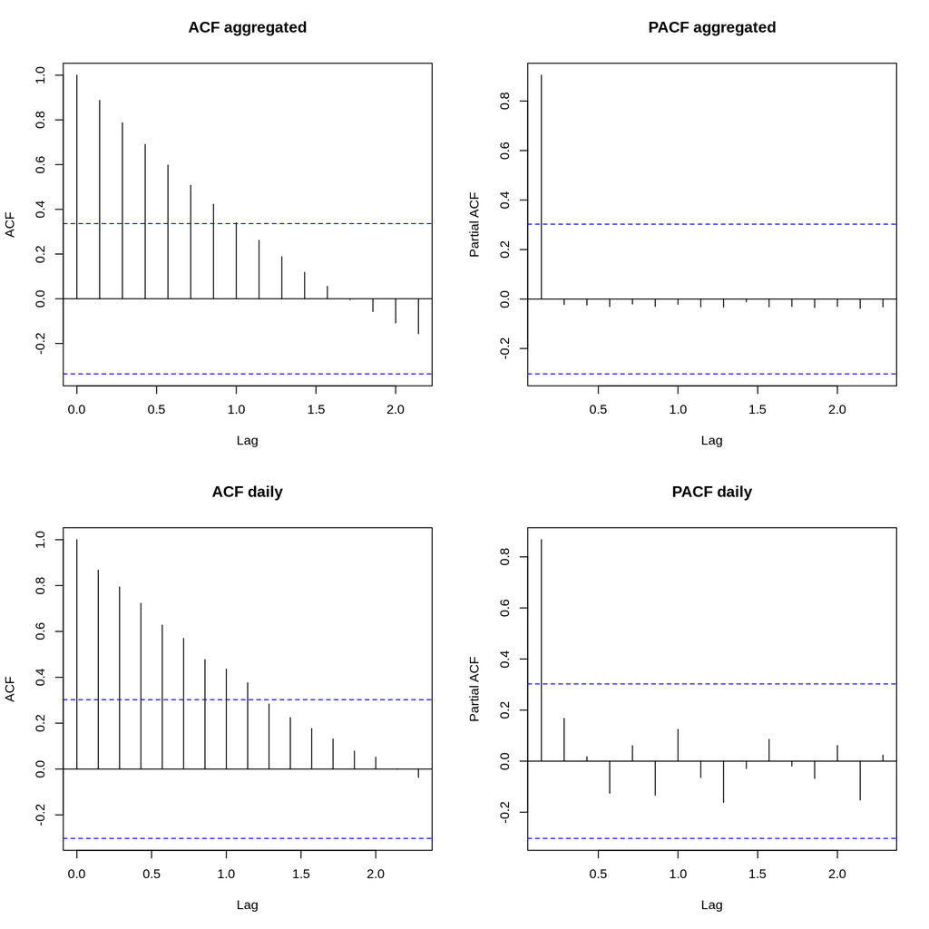

# BOX-LJUNG TEST

```
    Box-Ljung test

data:  ts_a_train
X-squared = 29.191, df = 1, p-value = 6.557e-08
```

```
    Box-Ljung test

data:  ts_d_train
X-squared = 20.037, df = 1, p-value = 7.594e-06
```

# AR(p): Auto-Regression of order p

Autoregression of the evolving variable on its own lagged values: given a time series $(X_{t})_{t}$, there exist an integer p and real coefficients $\alpha_1, \alpha_2, ..., \alpha_p$ such that

$$X_{t}= \mu + \alpha_1X_{t-1}+ ...+ \alpha_pX_{t-p}+ \epsilon_t, \quad t=1,2,....$$
The parameter $\alpha_i$ is the partial autocorrelation at lag $i$.

# MA(q): Moving Average of order q

There exist a parameter $q$ and real coefficients $b_1, ...b_q$ such that

$$X_{t}= \mu_t + \epsilon_t + b_1\epsilon_{t-1}+ ...+ b_q\epsilon_{t-q}$$
where $\epsilon_1, \epsilon_2, ... \epsilon_q$ are independent random normal variables, all with mean 0.

# ARIMA Parameters

$\bullet \quad$ If the TS is non-seasonal

$ARIMA(p,d,q)$

- $p$ = order of autoregression part
- $d$ = order of the first differencing involved
- $q$ = order of moving average part

$\bullet \quad$ If ARIMA is seasonal

$ARIMA(p,d,q)(p',d',q')_{freq}$

$p'$,$d'$,$q'$ are referred to the seasonal part of the time series.

# DECOMPOSITION OF THE AGGREGATED SET

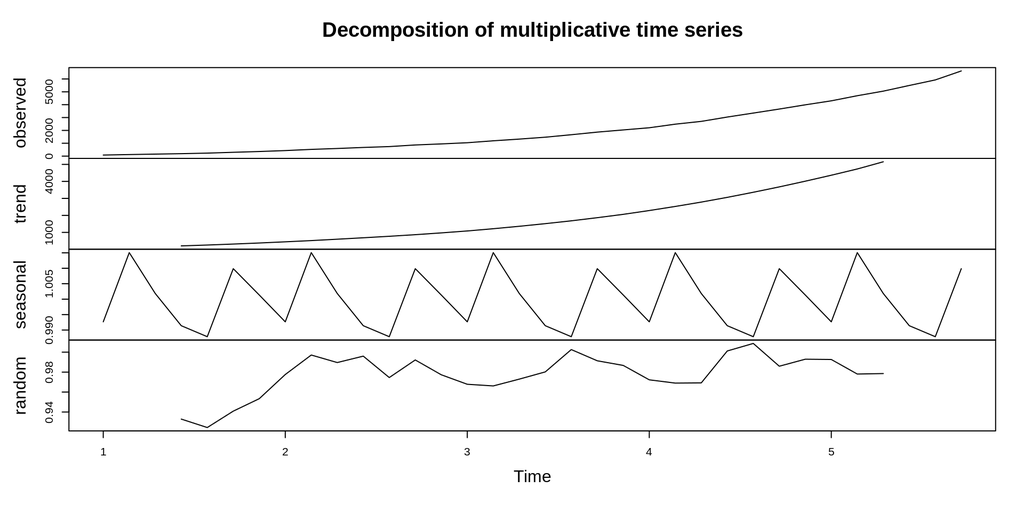

```r
dec_a_train <- decompose(ts_a_train, "multiplicative")
plot(dec_a_train)
```

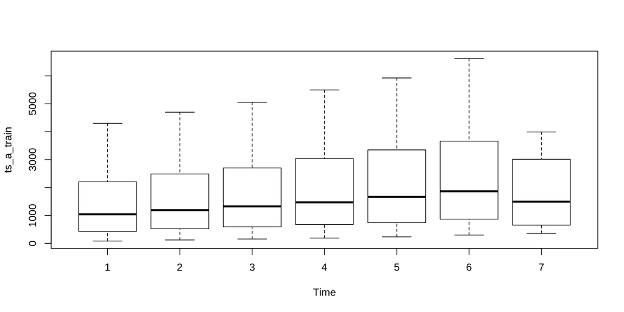

```r
boxplot(ts_a_train~cycle(ts_a_train),xlab="Time")
```

# DECOMPOSITION OF THE DAILY SET

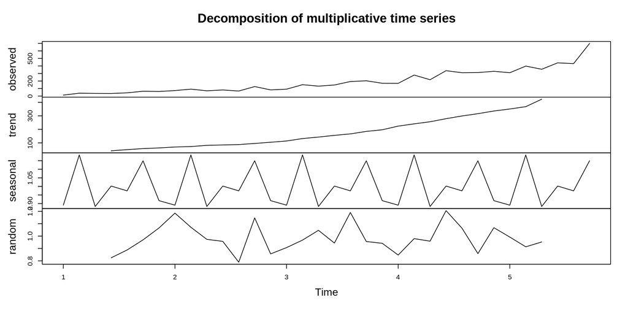

```r
dec_d_train <- decompose(ts_d_train, "multiplicative");
plot(dec_d_train)
```

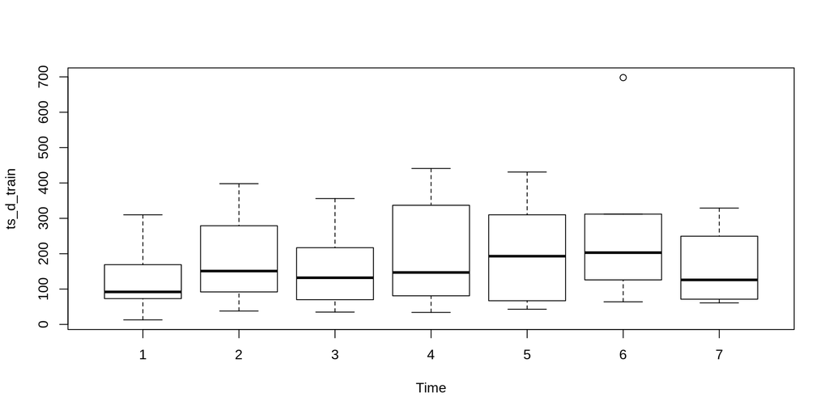

```r
boxplot(ts_d_train~cycle(ts_d_train),xlab="Time")
```

# AUTORIMA

```r
param_a <- auto.arima(ts_a_all, trace = TRUE, stepwise=FALSE, approximation = FALSE, method = "CSS-ML")
```

```
 ARIMA(0,2,0)                              : 463.5023
 ARIMA(0,2,0)(0,0,1)[7]                    : 462.3927
 ARIMA(0,2,0)(0,0,2)[7]                    : 461.1842
 ARIMA(0,2,0)(1,0,0)[7]                    : 460.774
 ARIMA(0,2,0)(1,0,1)[7]                    : Inf
 ARIMA(0,2,0)(1,0,2)[7]                    : Inf
 ARIMA(0,2,0)(2,0,0)[7]                    : Inf
 ARIMA(0,2,0)(2,0,1)[7]                    : Inf
 ARIMA(0,2,0)(2,0,2)[7]                    : Inf
 ARIMA(0,2,1)                              : 459.6871
 ARIMA(0,2,1)(0,0,1)[7]                    : 457.5624
 ARIMA(0,2,1)(0,0,2)[7]                    : 455.4963
 ARIMA(0,2,1)(1,0,0)[7]                    : 454.73
 ARIMA(0,2,1)(1,0,1)[7]                    : Inf
 ARIMA(0,2,1)(1,0,2)[7]                    : Inf
 ARIMA(0,2,1)(2,0,0)[7]                    : 453.191
 ARIMA(0,2,1)(2,0,1)[7]                    : 455.7922
 ARIMA(0,2,1)(2,0,2)[7]                    : 458.1101
 ARIMA(0,2,2)                              : 453.9665
 ARIMA(0,2,2)(0,0,1)[7]                    : 453.5068
 ARIMA(0,2,2)(0,0,2)[7]                    : 452.0416
 ARIMA(0,2,2)(1,0,0)[7]                    : 451.1235
 ARIMA(0,2,2)(1,0,1)[7]                    : Inf
 ARIMA(0,2,2)(1,0,2)[7]                    : Inf
 ARIMA(0,2,2)(2,0,0)[7]                    : Inf
 ARIMA(0,2,2)(2,0,1)[7]                    : 453.3245
 ARIMA(0,2,3)                              : 454.5326
 ARIMA(0,2,3)(0,0,1)[7]                    : 453.576
 ARIMA(0,2,3)(0,0,2)[7]                    : 453.067
 ARIMA(0,2,3)(1,0,0)[7]                    : 451.1962
 ARIMA(0,2,3)(1,0,1)[7]                    : Inf
 ARIMA(0,2,3)(2,0,0)[7]                    : 451.7409
 ARIMA(0,2,4)                              : 457.056
 ARIMA(0,2,4)(0,0,1)[7]                    : 456.334
 ARIMA(0,2,4)(1,0,0)[7]                    : 453.839
 ARIMA(0,2,5)                              : Inf
 ARIMA(1,2,0)                              : 456.6625
 ARIMA(1,2,0)(0,0,1)[7]                    : 455.5024
 ARIMA(1,2,0)(0,0,2)[7]                    : 453.0336
 ARIMA(1,2,0)(1,0,0)[7]                    : 453.3889
```

[output cut: 45 more lines]

```
 ARIMA(3,2,0)(1,0,1)[7]                    : Inf
 ARIMA(3,2,0)(2,0,0)[7]                    : Inf
 ARIMA(3,2,1)                    : Inf
 ARIMA(3,2,1)(0,0,1)[7]                    : Inf
 ARIMA(3,2,1)(1,0,0)[7]                    : Inf
 ARIMA(3,2,2)                    : Inf
 ARIMA(4,2,0)                              : 457.0126
 ARIMA(4,2,0)(0,0,1)[7]                    : 457.6171
 ARIMA(4,2,0)(1,0,0)[7]                    : 456.1069
 ARIMA(4,2,1)                    : Inf
 ARIMA(5,2,0)                              : 451.3902



 Best model: ARIMA(1,2,3)
```

```
Series: ts_a_all
ARIMA(1,2,3)

Coefficients:
         ar1      ma1     ma2      ma3
      0.9876  -1.8326  1.0924  -0.1547
s.e.  0.0193   0.1532  0.2551   0.1410

sigma^2 estimated as 3116:  log likelihood=-217.36
AIC=444.72   AICc=446.49   BIC=453.17
```

# A MANUAL TRY: diff()

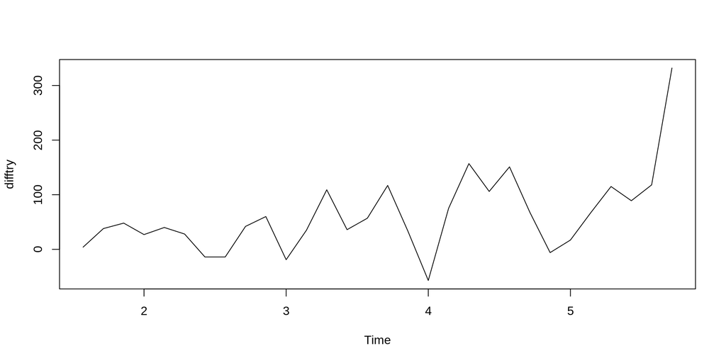

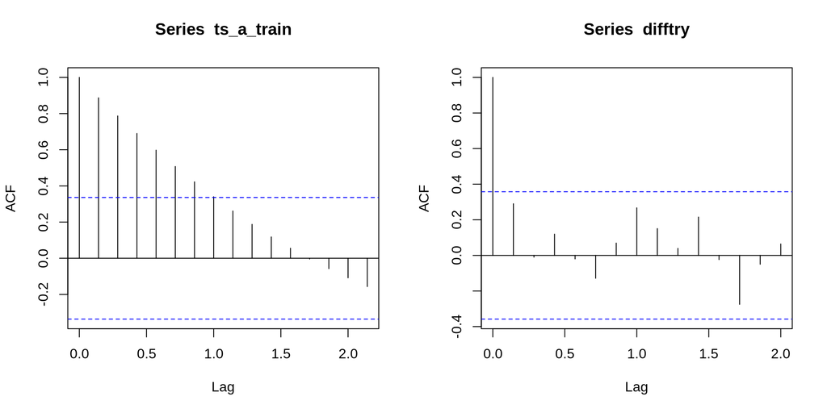

```r
difftry <- diff(ts_a_train, lag=2,  differences=2)
plot(difftry)
```

# ARIMA for Aggregated Data

```r
arima_a.fit <- Arima(ts_a_train, order= c(1,2,3), method = "ML", include.drift = FALSE)
arima_a.fit
```

```
Series: ts_a_train
ARIMA(1,2,3)

Coefficients:
         ar1      ma1     ma2      ma3
      0.9759  -1.5369  1.0661  -0.4094
s.e.  0.0455   0.2462  0.3696   0.2061

sigma^2 estimated as 3254:  log likelihood=-173.49
AIC=356.97   AICc=359.28   BIC=364.3
```

# Residuals Analysis for Aggregated Data

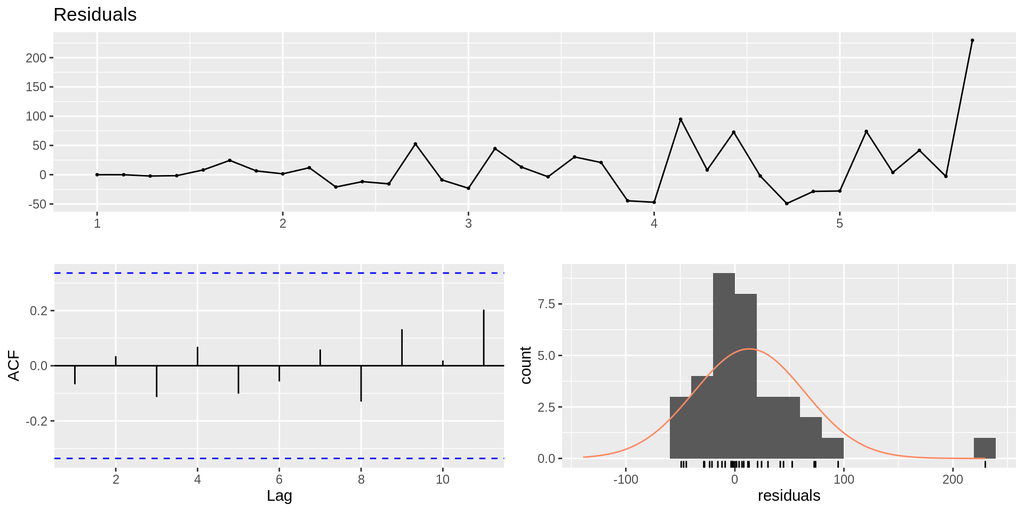

```
    Box-Ljung test

data:  arima_a.fit$resid
X-squared = 0.16698, df = 1, p-value = 0.6828
```

# FORECAST of Aggregated Data

```r
predict.fit <- forecast(arima_a.fit, level = c(95), h = 8)
```

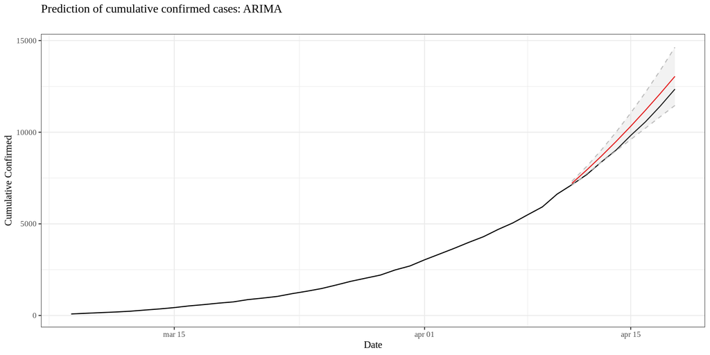

### AGGREGATED vs DAILY

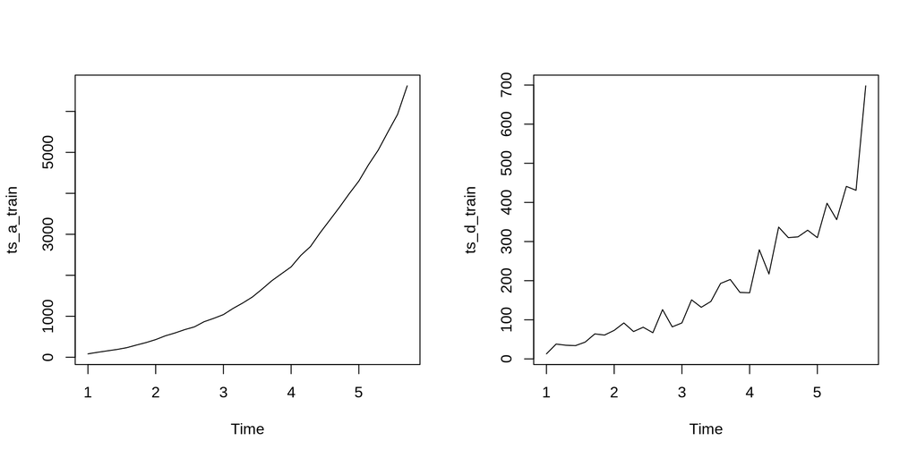

# AUTOARIMA for Daily Data

```r
param_d <- auto.arima(ts_d_all, stepwise = FALSE, approximation = FALSE, method = "CSS-ML")
param_d
```

```
Series: ts_d_all
ARIMA(1,1,2)(2,0,0)[7]

Coefficients:
         ar1      ma1     ma2    sar1    sar2
      0.9781  -1.7132  0.8148  0.1517  0.3716
s.e.  0.0368   0.1364  0.1173  0.1481  0.1958

sigma^2 estimated as 2665:  log likelihood=-220.61
AIC=453.22   AICc=455.69   BIC=463.5
```

# ARIMA for Daily Data

```r
arima_d.fit <- Arima(ts_d_train, order = c(1, 1, 2), seasonal = c(2, 0, 0), method = "ML", include.drift = FALSE)
arima_d.fit
```

```
Series: ts_d_train
ARIMA(1,1,2)(2,0,0)[7]

Coefficients:
          ar1      ma1     ma2    sar1    sar2
      -0.3073  -0.1605  0.3766  0.2206  0.2503
s.e.   0.5204   0.4761  0.2848  0.2231  0.2580

sigma^2 estimated as 3324:  log likelihood=-178.98
AIC=369.97   AICc=373.2   BIC=378.95
```

# Residual Analysis for Daily Data

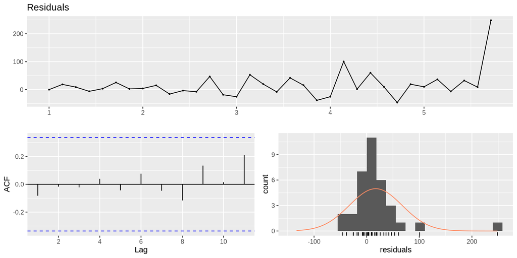

```
    Box-Ljung test

data:  arima_d.fit$resid
X-squared = 0.25159, df = 1, p-value = 0.616
```

# FORECAST for Daily Data

```r
predict.fit <- forecast(arima_d.fit, level = c(95), h = 8)
```

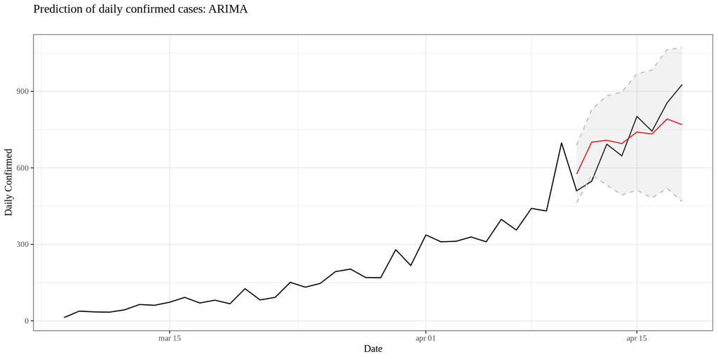